# Insurance Charges Analysis

Samira Ouattara

2026-10-15

# Introduction

Health insurers set prices based on how much they expect to pay out in claims. This analysis looks at what drives individual insurance charges.

The dataset has 1,338 people with their age, sex, BMI, number of children, smoking status, region, and yearly insurance charges.

The goal is to answer two questions:

- Which factors are related to higher charges?
- How much does each factor change the charges?

I start by exploring the data with counts and plots, then check correlations, and finish with two regression models: a log-linear model and a Gamma GLM.

# Load and check the data

```r
df <- read_csv("insurance.csv")
head(df)
```

```
## # A tibble: 6 × 7
##     age sex      bmi children smoker region    charges
##   <dbl> <chr>  <dbl>    <dbl> <chr>  <chr>       <dbl>
## 1    19 female  27.9        0 yes    southwest  16885.
## 2    18 male    33.8        1 no     southeast   1726.
## 3    28 male    33          3 no     southeast   4449.
## 4    33 male    22.7        0 no     northwest  21984.
## 5    32 male    28.9        0 no     northwest   3867.
## 6    31 female  25.7        0 no     southeast   3757.
```

```r
colSums(is.na(df))
```

```
##      age      sex      bmi children   smoker   region  charges
##        0        0        0        0        0        0        0
```

```r
summary(df)
```

```
##       age            sex                 bmi           children
##  Min.   :18.00   Length:1338        Min.   :15.96   Min.   :0.000
##  1st Qu.:27.00   Class :character   1st Qu.:26.30   1st Qu.:0.000
##  Median :39.00   Mode  :character   Median :30.40   Median :1.000
##  Mean   :39.21                      Mean   :30.66   Mean   :1.095
##  3rd Qu.:51.00                      3rd Qu.:34.69   3rd Qu.:2.000
##  Max.   :64.00                      Max.   :53.13   Max.   :5.000
##     smoker             region             charges
##  Length:1338        Length:1338        Min.   : 1122
##  Class :character   Class :character   1st Qu.: 4740
##  Mode  :character   Mode  :character   Median : 9382
##                                        Mean   :13270
##                                        3rd Qu.:16640
##                                        Max.   :63770
```

No missing values. Ages range from 18 to 64.

# Explore

```r
df %>% count(sex)
```

```
## # A tibble: 2 × 2
##   sex        n
##   <chr>  <int>
## 1 female   662
## 2 male     676
```

```r
df %>% count(region)
```

```
## # A tibble: 4 × 2
##   region        n
##   <chr>     <int>
## 1 northeast   324
## 2 northwest   325
## 3 southeast   364
## 4 southwest   325
```

```r
df %>% count(children)
```

```
## # A tibble: 6 × 2
##   children     n
##      <dbl> <int>
## 1        0   574
## 2        1   324
## 3        2   240
## 4        3   157
## 5        4    25
## 6        5    18
```

## Distributions

Histogram of charges: right-skewed, most people have low charges and a few have very high ones (this is why we log it later)

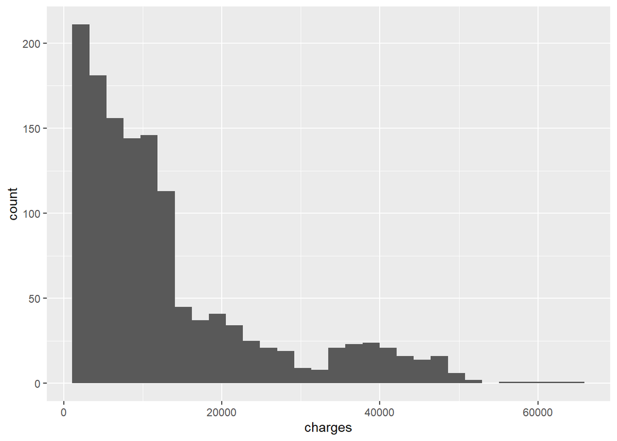

```r
ggplot(df, aes(x = charges)) +
  geom_histogram(bins = 30)
```

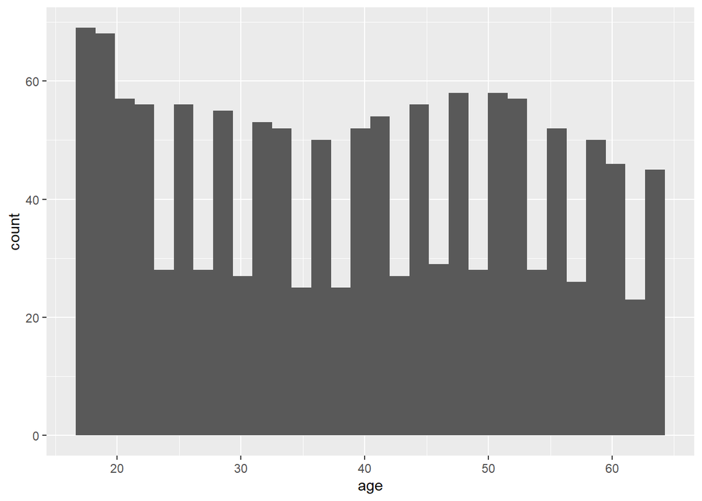

```r
ggplot(df, aes(x = age)) +
  geom_histogram(bins = 30)
```

## Charges by group

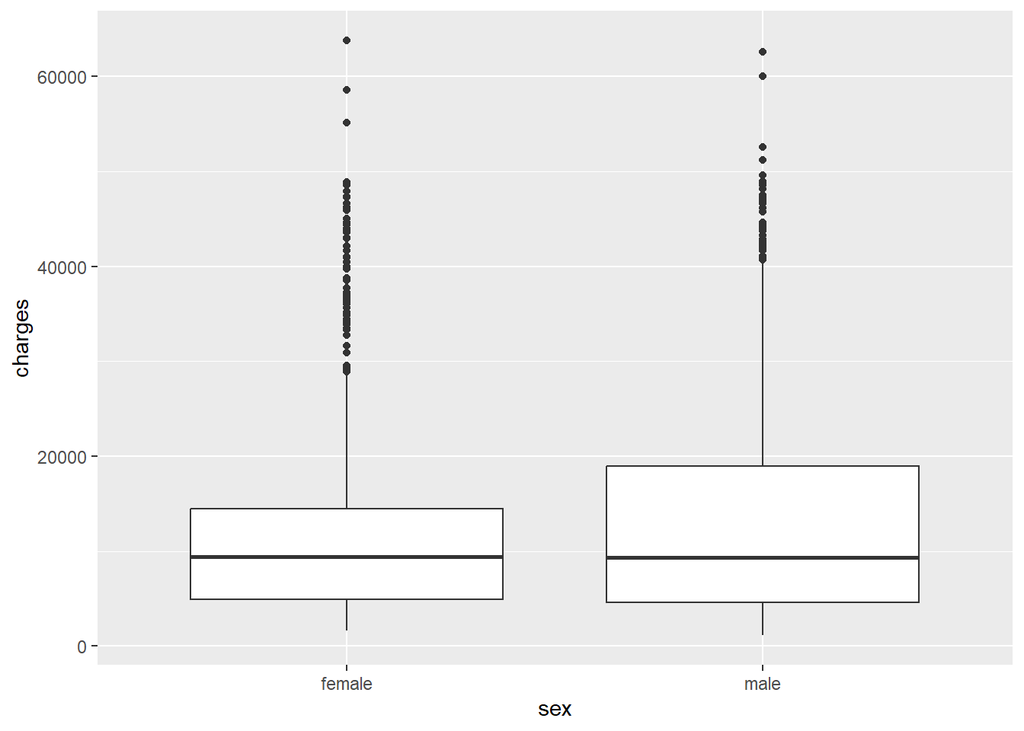

```r
ggplot(df, aes(x = sex, y = charges)) +
  geom_boxplot()
```

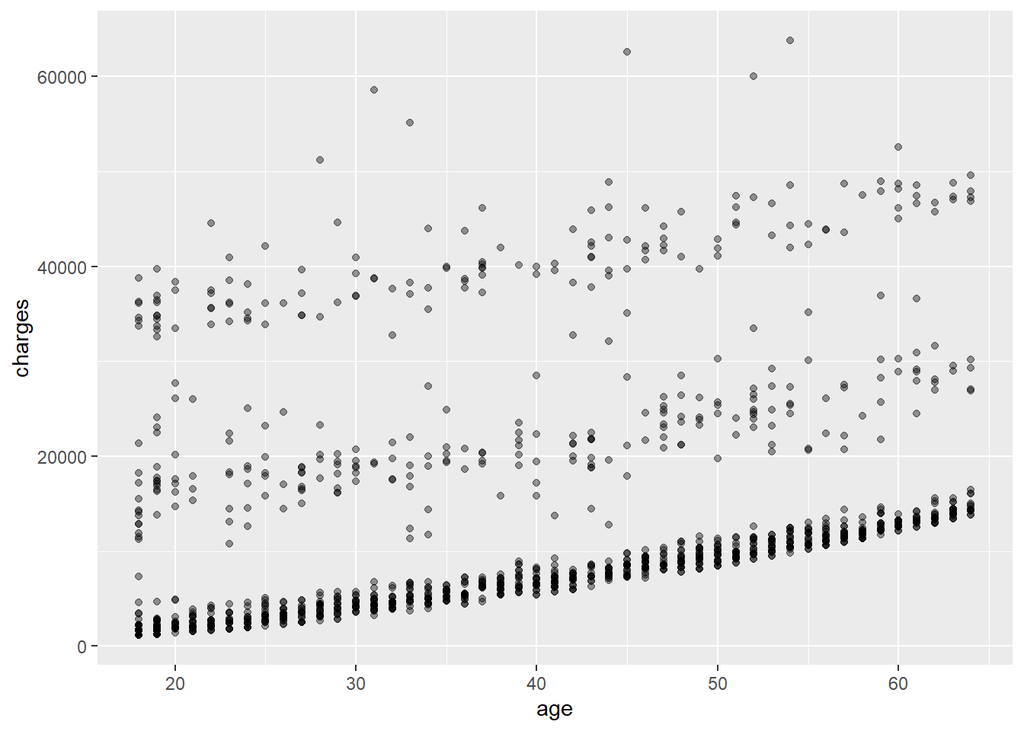

```r
ggplot(df, aes(x = age, y = charges)) +
  geom_point(alpha = 0.4)
```

## Pie charts

Pie charts: share of each group for sex, region, smoker and children

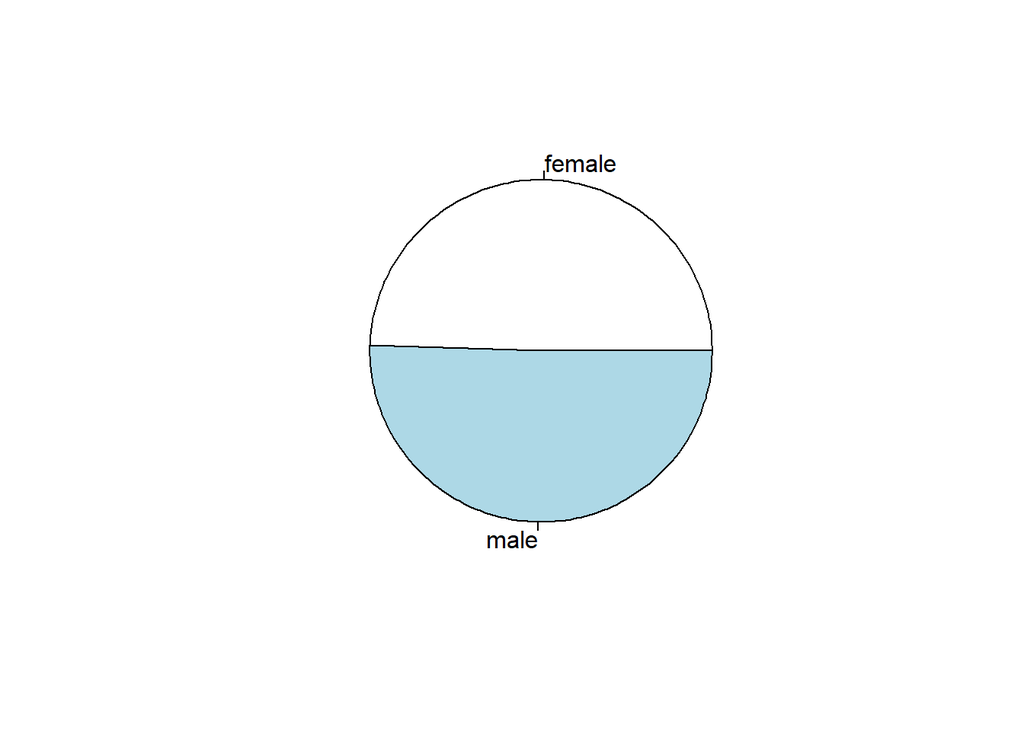

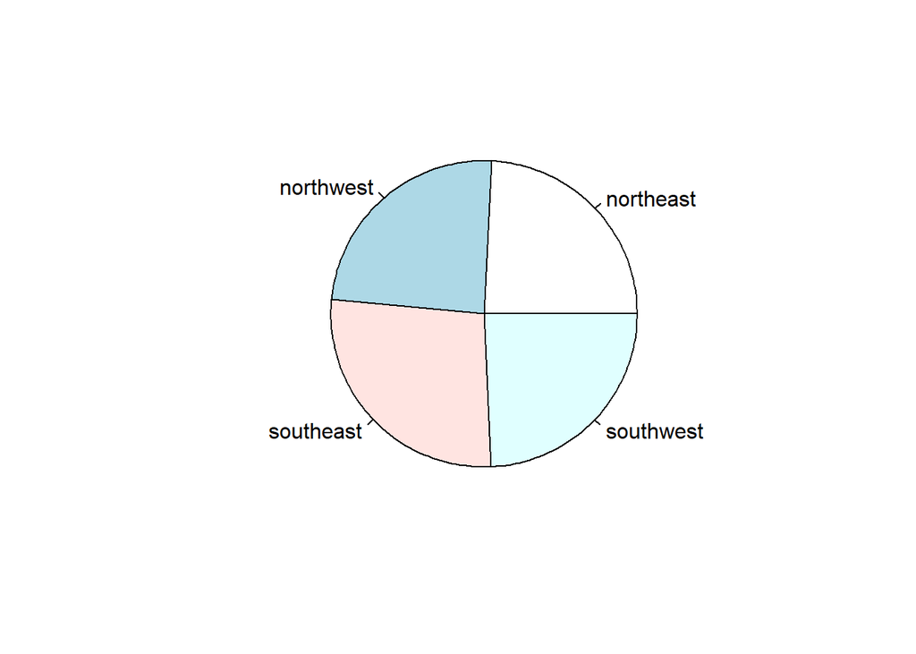

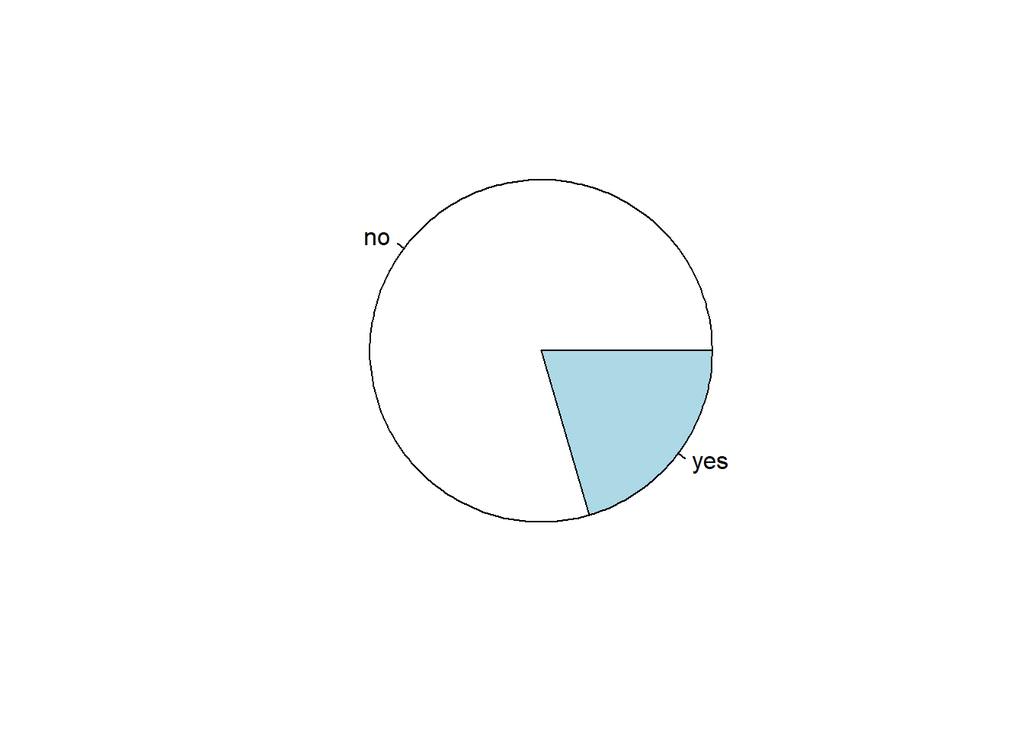

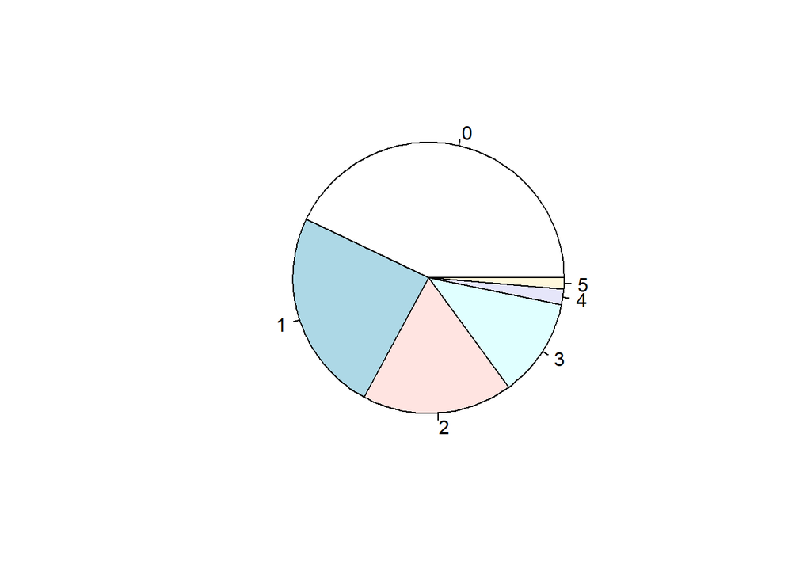

```r
pie(table(df$sex))
pie(table(df$region))
pie(table(df$smoker))
pie(table(df$children))
```

# Correlations

## Are children related to charges?

```r
cor.test(df$children, df$charges)
```

```
##
##  Pearson's product-moment correlation
##
## data:  df$children and df$charges
## t = 2.4912, df = 1336, p-value = 0.01285
## alternative hypothesis: true correlation is not equal to 0
## 95 percent confidence interval:
##  0.0144600 0.1211477
## sample estimates:
##        cor
## 0.06799823
```

Weak link. The correlation is only 0.07. The p-value (0.013) says it is not zero, but the effect is too small to matter on its own.

## Is age related to charges?

```r
cor.test(df$age, df$charges)
```

```
##
##  Pearson's product-moment correlation
##
## data:  df$age and df$charges
## t = 11.453, df = 1336, p-value < 2.2e-16
## alternative hypothesis: true correlation is not equal to 0
## 95 percent confidence interval:
##  0.2494139 0.3470381
## sample estimates:
##       cor
## 0.2990082
```

Moderate positive link (0.30). Older people tend to pay more. The p-value is almost zero, so this is a real pattern, not noise.

## What about smoking?

Smoking is coded 1 for yes and 0 for no so we can correlate it.

```r
df$smoker_num <- ifelse(df$smoker == "yes", 1, 0)
cor.test(df$smoker_num, df$charges)
```

```
##
##  Pearson's product-moment correlation
##
## data:  df$smoker_num and df$charges
## t = 46.665, df = 1336, p-value < 2.2e-16
## alternative hypothesis: true correlation is not equal to 0
## 95 percent confidence interval:
##  0.7659767 0.8068037
## sample estimates:
##       cor
## 0.7872514
```

Strong positive link (0.79). Smokers pay much more. Smoking alone explains about 62% of the variation in charges, so it is the strongest factor so far. Next step is a regression to see what else matters once smoking is accounted for.

# Log-linear regression

```r
model <- lm(log(charges) ~ age + bmi + children + smoker + sex + region,
            data = df)
summary(model)
```

```
##
## Call:
## lm(formula = log(charges) ~ age + bmi + children + smoker + sex +
##     region, data = df)
##
## Residuals:
##      Min       1Q   Median       3Q      Max
## -1.07186 -0.19835 -0.04917  0.06598  2.16636
##
## Coefficients:
##                   Estimate Std. Error t value Pr(>|t|)
## (Intercept)      7.0305581  0.0723960  97.112  < 2e-16 ***
## age              0.0345816  0.0008721  39.655  < 2e-16 ***
## bmi              0.0133748  0.0020960   6.381 2.42e-10 ***
## children         0.1018568  0.0100995  10.085  < 2e-16 ***
## smokeryes        1.5543228  0.0302795  51.333  < 2e-16 ***
## sexmale         -0.0754164  0.0244012  -3.091 0.002038 **
## regionnorthwest -0.0637876  0.0349057  -1.827 0.067860 .
## regionsoutheast -0.1571967  0.0350828  -4.481 8.08e-06 ***
## regionsouthwest -0.1289522  0.0350271  -3.681 0.000241 ***
## ---
## Signif. codes:  0 '***' 0.001 '**' 0.01 '*' 0.05 '.' 0.1 ' ' 1
##
## Residual standard error: 0.4443 on 1329 degrees of freedom
## Multiple R-squared:  0.7679, Adjusted R-squared:  0.7666
## F-statistic: 549.8 on 8 and 1329 DF,  p-value: < 2.2e-16
```

- Model explains about 77% of the variation in log charges (adj. R2 = 0.767).
- Smoking is the biggest driver: smokers pay about 4.7x more, holding everything else constant.
- Each extra child adds about 11%, each year of age about 3.5%, each BMI point about 1.3%.
- Males pay about 7% less than females. Southeast and southwest are about 12 to 15% lower than northeast.
- Northwest is not significant (p = 0.068).
- Residual SE is 0.44 on the log scale, and some large outliers remain.

## Why log?

Charges are right-skewed and the spread grows with the mean, which breaks the assumptions of plain linear regression. Compare the diagnostics.

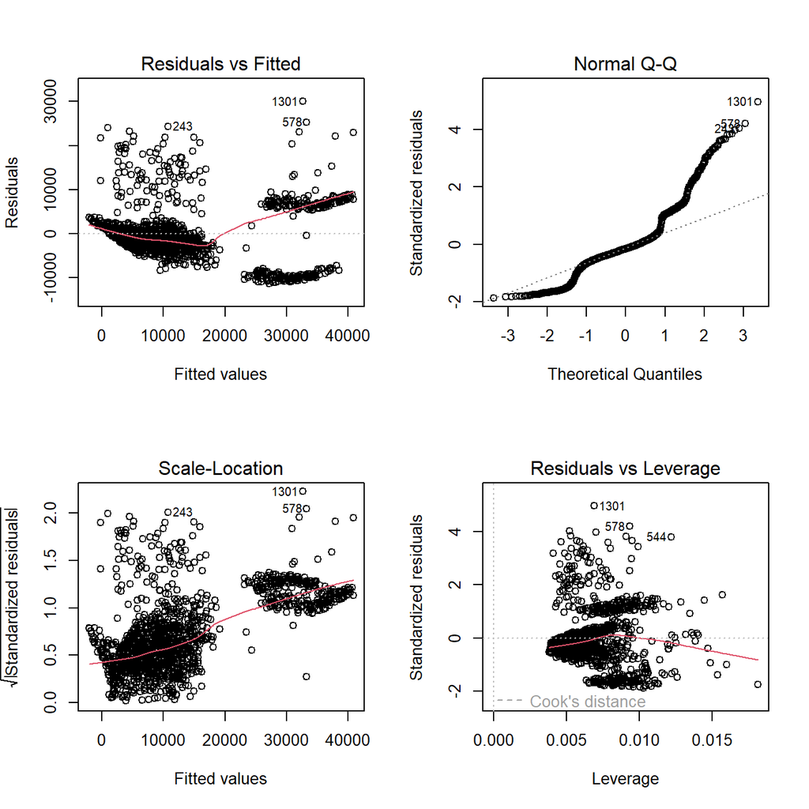

```r
m_raw <- lm(charges ~ age + bmi + children + smoker + sex + region, data = df)

par(mfrow = c(2, 2))
plot(m_raw)
```

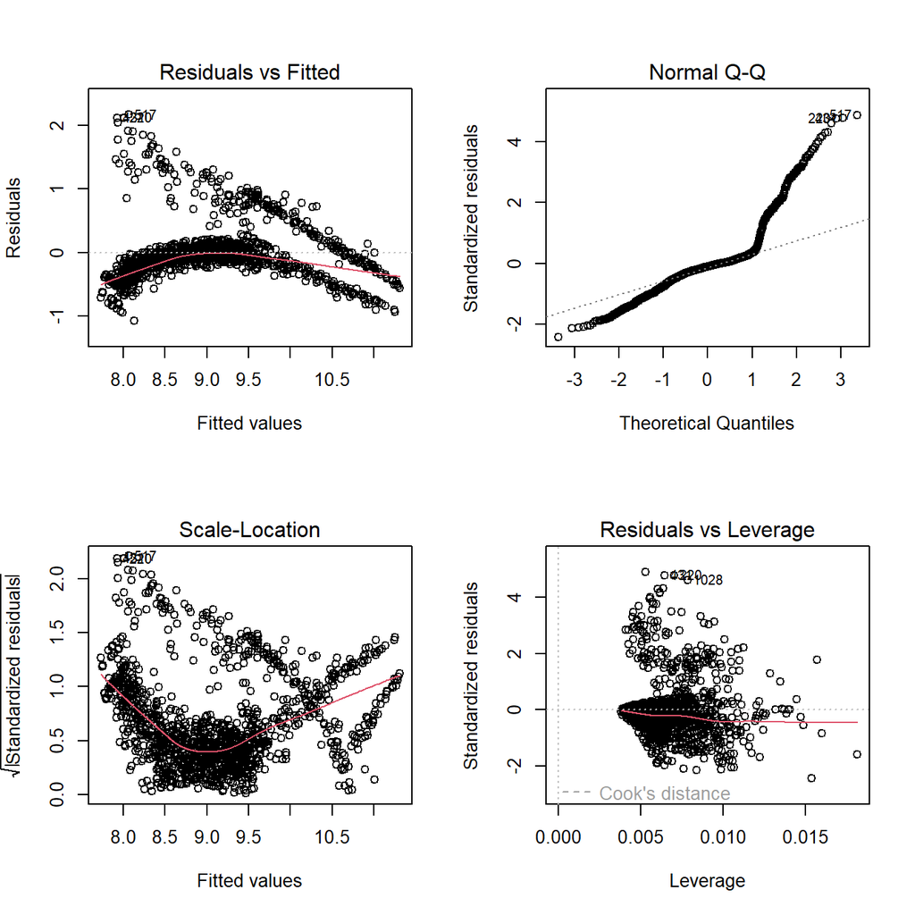

```r
plot(model)
```

```r
par(mfrow = c(1, 1))
```

# Gamma GLM

```r
glm_model <- glm(charges ~ age + bmi + children + smoker + sex + region,
                 data = df,
                 family = Gamma(link = "log"))
summary(glm_model)
```

```
##
## Call:
## glm(formula = charges ~ age + bmi + children + smoker + sex +
##     region, family = Gamma(link = "log"), data = df)
##
## Deviance Residuals:
##      Min        1Q    Median        3Q       Max
## -1.13342  -0.33710  -0.14819  -0.01247   2.72451
##
## Coefficients:
##                  Estimate Std. Error t value Pr(>|t|)
## (Intercept)      7.386342   0.111350  66.334  < 2e-16 ***
## age              0.028638   0.001341  21.351  < 2e-16 ***
## bmi              0.014123   0.003224   4.381 1.28e-05 ***
## children         0.084173   0.015534   5.419 7.12e-08 ***
## smokeryes        1.500330   0.046572  32.215  < 2e-16 ***
## sexmale         -0.057079   0.037531  -1.521  0.12854
## regionnorthwest -0.057875   0.053687  -1.078  0.28123
## regionsoutheast -0.141637   0.053960  -2.625  0.00877 **
## regionsouthwest -0.145484   0.053874  -2.700  0.00701 **
## ---
## Signif. codes:  0 '***' 0.001 '**' 0.01 '*' 0.05 '.' 0.1 ' ' 1
##
## (Dispersion parameter for Gamma family taken to be 0.4669548)
##
##     Null deviance: 1056.04  on 1337  degrees of freedom
## Residual deviance:  337.73  on 1329  degrees of freedom
## AIC: 26379
##
## Number of Fisher Scoring iterations: 7
```

```r
# percent effects
round((exp(coef(glm_model)) - 1) * 100, 1)
```

```
##     (Intercept)             age             bmi        children       smokeryes
##        161279.2             2.9             1.4             8.8           348.3
##         sexmale regionnorthwest regionsoutheast regionsouthwest
##            -5.5            -5.6           -13.2           -13.5
```

```r
# pseudo R-squared
1 - glm_model$deviance / glm_model$null.deviance
```

```
## [1] 0.6801956
```

- Pseudo R2 = 0.68 (1 - residual deviance / null deviance). AIC = 26,379.
- Smoker is the biggest driver: smokers pay about 4.5x more, holding everything else constant.
- Each extra child adds about 9%, each year of age about 3%, each BMI point about 1.4%.
- Southeast and southwest are about 13% lower than northeast (both significant).
- Sex and northwest are not significant (p = 0.129 and 0.281).
- Results match the log-lm model, so conclusions don’t depend on the method.

# Log-linear vs GLM

Both models agree on the story: smoking is the biggest driver, then children, age and BMI, and the southern regions pay less. The GLM gives slightly smaller effects because it works on average dollars. The only real difference is sex: significant in the log-linear model but not in the GLM, so it is a weak effect. Log-linear is simpler to explain. GLM is better for predicting dollar amounts.

# Conclusion

Smoking is the biggest driver of insurance charges in this dataset. Smokers pay about 4.5 to 4.7x more than non-smokers, holding everything else constant. On its own, smoking explains about 62% of the variation in charges.

Age, BMI, and number of children also raise charges. Each year of age adds about 3%, each BMI point about 1.4%, and each child about 9 to 11%. Southeast and southwest are about 13% cheaper than northeast.

Sex and the northwest region had no clear effect. Sex was significant in the log-linear model but not in the Gamma GLM, so it is a weak effect at best.

Charges are right-skewed, so I modeled them on a log scale. The log-linear model (adj. R2 = 0.77) and the Gamma GLM (pseudo R2 = 0.68) gave the same story, so the conclusions do not depend on the method.

Limits: these are associations, not proof of cause, and some large outliers remain that the models do not explain well.